# IODS course project

Roni Koitermaa

21 November, 2023

# 1 About the project

Introduction to Open Data Science is a course combining open data, open science and data science. The course aims to provide tools and techniques for visualizing, analyzing and interpreting data using the methods of data science. Open research tools such as R, R Markdown and RStudio are used to produce dynamic and reproducible reports combining text and R code, which are published on GitHub pages. Reproducible research makes scientific research transparent by providing access to both data and code, which allows anyone to evaluate how data analysis has been done.

These pages are a learning diary to document progress on the course.

GitHub pages: https://roninkoi.github.io/IODS-project  
GitHub repository: https://github.com/Roninkoi/IODS-project

## 1.1 Initial thoughts

I found out about this course from the doctoral school mailing list, and thought it would help me improve my data analysis skills and teach me how to make scientific research more open. I’m interested in learning R, and this course is a good chance to do so. I have been using Python with Matplotlib/NumPy/SciPy to visualize and analyze data previously, so I’m curious to see the benefits of using R.

## 1.2 Learning R (week 1)

After reading chapters 1-4 of R for Health Data Science (Harrison and Pius 2021), I have found it to be a useful introduction to R so far. It’s very good that this book is openly available and itself written using R. It focuses quite heavily on practical examples, which has been good for learning. I had the most difficulty with chapter 2 on R basics. The way some things are done in R seemed a bit unusual and opaque. I was most interested in finding out how R differs from other languages, since I’m familiar with most basic concepts. The most interesting chapter so far has been chapter 4 on plotting, and I’ve always found making plots to be fun.

The RStudio IDE makes working with R and R Markdown easy, but I personally find it a bit clumsy compared to a simple text editor. The main benefit of RStudio has been easy editing of R Markdown, with the ability to evaluate single R blocks and visualization of the results (tables, plots).

- Installed R and RStudio, forked IODS-project repository (Vehkalahti 2020), set up GitHub pages
- Write chapter1.Rmd
- Add author to index.Rmd
- Created GitHub access token
- Commit and push to GitHub

# 2 Regression and model validation (week 2)

Academic performance of students depends on many factors, which may be difficult to measure and model accurately. The grade that a student gets may be attributable to qualities of each student, e.g. motivation and previous knowledge, but the exact relationship between these is not directly measurable. Linear regression is one of the simplest ways to quantify the relationship $f$ between predictor variables $X$ and a response variable $Y$ using a linear model $\hat Y = \hat f(X)$ (James et al. 2021). By fitting a model to a data set, we can determine the prediction $\hat Y$ by finding an estimate for $\hat f$. If we have the appropriate data set available, it should be possible to roughly predict how well a student performs using a model.

A data set on student learning was created for regression analysis. This data set is based on student learning data[^1] collected in 2014-2015, which describes student learning attitudes and outcomes. The data includes scores from surveys answered by the students, which are used to construct variables that describe different aspects of learning.

An R script was created in [`data/create_learning2014.R`](https://github.com/Roninkoi/IODS-project/blob/master/data/create_learning2014.R) to generate the data set. The raw data contains 183 rows and 60 variables (described in more detail in the code). We include student gender, age and exam points from the raw data in our data set. Additionally, we create variables based on the description in the metadata[^2]. The data contains a number of questions $Q$ on different aspects of learning, which are classified into groups: deep learning $Q_\text{D}$, surface learning $Q_\text{SU}$ and strategic learning $Q_\text{ST}$. Scores for each group are calculated by simply taking the mean over each set of questions: $\text{D} = \overline Q_\text{D}, \ \text{SU} = \overline Q_\text{SU}, \ \text{ST} = \overline Q_\text{ST}.$ This is done similarly for questions on attitude towards statistics, which we also include in our data set. Now our data set consists of the 7 variables `gender`, `age`, `attitude`, `deep`, `stra`, `surf` and `points`. Finally, we filter the data such that it only contains students whose exam points are larger than 0, which leaves us with 166 students The finalized data set is written to `data/learning2014.csv`.

In figure 2.1, we can look at the correlations between variables to determine which are most significant for the exam scores. We can see that the most strongly correlated variable is `attitude`, which has a positive correlation coefficient of 0.437 (marked by three stars, indicating high confidence level). This means that for high `attitude` scores, we are likely to see high exam scores as well. We can even see that the shape of the `points` histogram slightly resebles the shape of the `attitude` one. The second and third most significant correlations are with `stra` (positive) and `surf` (negative). This suggests that a high strategic learning score is likely to lead to high exam scores, while surface learning is not. These two scores are also negatively correlated with each other, meaning that they represent somewhat opposite learning attitudes. Similarly, we see that a `deep` learning score is very negatively correlated with `surf`.`

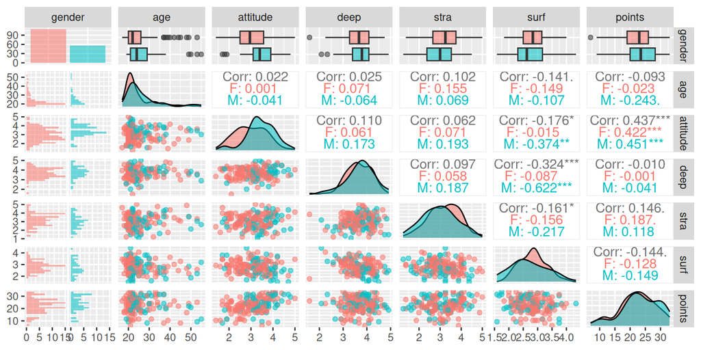

Figure 2.1: Scatter matrix of the learning2014 data set.

```r
# load data set
learning14 <- read_csv("./data/learning2014.csv")

# plot scatter matrix of variables
sm <- ggpairs(learning14, mapping = aes(colour=gender, alpha=0.7),
              lower = list(combo = wrap("facethist", bins = 20)))
sm
```

```r
# get summaries for different variables
age_summary <- summary(learning14$age)
attitude_summary <- summary(learning14$attitude)
deep_summary <- summary(learning14$deep)
surf_summary <- summary(learning14$surf)
stra_summary <- summary(learning14$stra)
points_summary <- summary(learning14$points)

# calculate number of students
n_students <- nrow(learning14)
n_men <- nrow(filter(learning14, gender == "M"))
n_women <- nrow(filter(learning14, gender == "F"))

kable(data.frame("Age"=c(age_summary[1], age_summary[3],
                         age_summary[4], age_summary[6]),
                 "Attitude"=c(attitude_summary[1], attitude_summary[3],
                              attitude_summary[4], attitude_summary[6]),
                 "Deep"=c(deep_summary[1], deep_summary[3],
                          deep_summary[4], deep_summary[6]),
                 "Surface"=c(surf_summary[1], surf_summary[3],
                             surf_summary[4], surf_summary[6]),
                 "Strategic"=c(stra_summary[1], stra_summary[3],
                               stra_summary[4], stra_summary[6]),
                 "Points"=c(points_summary[1], points_summary[3],
                            points_summary[4], points_summary[6])),
                 caption = sprintf("Summary of different variables for %i students (%i men, %i women).",
                                   n_students, n_men, n_women))
```

Table 2.1: Summary of different variables for 166 students (56 men, 110 women).

|  | Age | Attitude | Deep | Surface | Strategic | Points |
| --- | --- | --- | --- | --- | --- | --- |
| Min. | 17.00000 | 1.400000 | 1.583333 | 1.583333 | 1.250000 | 7.00000 |
| Median | 22.00000 | 3.200000 | 3.666667 | 2.833333 | 3.187500 | 23.00000 |
| Mean | 25.51205 | 3.142771 | 3.679719 | 2.787149 | 3.121235 | 22.71687 |
| Max. | 55.00000 | 5.000000 | 4.916667 | 4.333333 | 5.000000 | 33.00000 |

We want to fit a linear model $\hat f(x_1, x_2, x_3) = \beta_0 + \beta_1 x_1 + \beta_2 x_2 + \beta_3 x_3$ to the `learning2014` data set with 3 variables. To choose these variables, we first start by fitting all 7 of them. Fitting the linear model is done by using the `lm()` function. A summary of the fit is generated to get the coefficient values, p-values and $R^2$. The variable with the largest p-value is removed from the model, and the model is fitted again. We continue this process of elimination until only 3 variables are left: `age`, `attitude` and `stra`. The model with all variables “All” and the model with 3 variables “Linear” are shown in table 2.2 with their coefficients, p-values and $R^2$. We can see that the 3 variable model has lower p-values for `age` and `attitude`.

The p-values reported for coefficients are calculated using the $t$-test. We want to minimize the p-values for the coefficients of our fit in order to establish statistical significance. For our model’s coefficients to be statistically significant, we would typically like the $p$-value to be less than $5%$. Similarly, we want to maximize $R^2$, which is a measure of how good our model is at predicting the response based on the predictor variables (goodness of fit). It is defined using the errors of the fit as $R^2 = 1 - \text{RSS} / \text{TSS}$, where $\text{RSS}$ is the residual sum of squares and $\text{TSS}$ is the total sum of squares (James et al. 2021). By decreasing $SS_\text{res}$, we improve the fit and move $R^2$ closer to 1.

The linear model predicts the exam points using the equation $\hat f = 10.90 - 0.09 \ \text{age} + 3.48 \ \text{attitude} + 1.00 \ \text{stra}$ (table 2.2). The variable `attitude` is the most significant, followed by `stra`, accounting for the majority of the points. This suggests that positive attitudes towards the subject and strategic skills (organization, time management, …) play a significant factor in positive learning outcomes, which is an expected association. Age correlates slightly negatively with points, suggesting that younger people are more likely to earn higher scores. It could be that older people have less time to devote to studying, but other factors may also contribute to this.

Only the `attitude` parameter in the linear model has a p-value of less 5%, while `strategy` is fairly close at 6% and `age` at 10%. The $R^2$ score for the linear model is 0.218, so the model predicts about 22% of the score based on the chosen variables. The rest can’t be explained using the model, so they are due to external factors not accounted for by the model.

Comparisons for exam point histograms are shown in figure 2.2. These figures show the real exam point data with the predicted distribution from the linear model and best fit model. As can be seen, the point distribution is reproduced quite well, with the mean of the distribution roughly correct. Behavior at the tails shows the positions of the peaks (low and high), but their magnitude is overestimated.

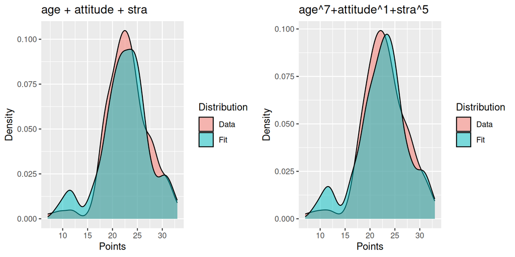

```r
# plot histogram of points for data and fit
fit_hist <- function (data, fit, title) {
  points <- data.frame(Points=c(data$points, predict(fit)),
                     Distribution=c("Data", "Fit"))

  ggplot(points, aes(Points, fill = Distribution)) +
    geom_density(alpha = 0.5) + ylab("Density") + ggtitle(title)
}

# first fit full 7 variable linear model and remove variables based on p-value
fit_full <- lm(points ~ ., data = learning14)
fit_full_summary <- summary(fit_full)

# linear model with 3 most significant variables: age, attitude, stra
fit_lin <- lm(points ~ age + attitude + stra, data = learning14)
fit_lin_summary <- summary(fit_lin)
hist1 <- fit_hist(learning14, fit_lin, title = "age + attitude + stra")

# try to find better model by fitting x^p with varying p
max_r2 <- 0
max_ijk <- c(0, 0, 0)
fit_best <- fit_lin
pn <- 10
for (i in 1:pn) {
  for (j in 1:pn) {
    for (k in 1:pn) {
      # fit model with 3 parameters and varying powers
      fit_ijk <- lm(points ~ I(age^i) + I(attitude^j) + I(stra^k),
                    data = learning14)
      fit_summary <- summary(fit_ijk)

      # is p-value low enough for all parameters?
      good_p <- !any(array(summary(fit_ijk)$coefficients[,4]) > 0.05)

      # if r2 better than best found so far, accept this fit
      if (fit_summary$r.squared > max_r2 && good_p) {
        max_r2 <- fit_summary$r.squared
        max_ijk <- c(i, j, k)
        fit_best <- fit_ijk
      }
    }
  }
}

fit_best_summary <- summary(fit_best)
message("best fit: (", max_ijk[1], ", ", max_ijk[2], ", ", max_ijk[3],
        "), R2: ", max_r2)

hist2 <- fit_hist(learning14, fit_best,
                  sprintf("age^%i+attitude^%i+stra^%i",
                          max_ijk[1], max_ijk[2], max_ijk[3]))

grid.arrange(hist1, hist2, ncol=2, respect=T)
```

```r
fe <- data.frame("Fit"=c("Intercept", "Intercept p-value",
                         "Age", "Age p-value",
                         "Attitude", "Attitude p-value",
                         "Strategy", "Strategy p-value", "R^2"),
                 "All"=c(fit_full_summary$coefficients[1,1],
                         fit_full_summary$coefficients[1,4],
                         fit_full_summary$coefficients[2,1],
                         fit_full_summary$coefficients[2,4],
                         fit_full_summary$coefficients[3,1],
                         fit_full_summary$coefficients[3,4],
                         fit_full_summary$coefficients[4,1],
                         fit_full_summary$coefficients[4,4],
                         fit_full_summary$r.squared),
                 "Linear"=c(fit_lin_summary$coefficients[1,1],
                            fit_lin_summary$coefficients[1,4],
                            fit_lin_summary$coefficients[2,1],
                            fit_lin_summary$coefficients[2,4],
                            fit_lin_summary$coefficients[3,1],
                            fit_lin_summary$coefficients[3,4],
                            fit_lin_summary$coefficients[4,1],
                            fit_lin_summary$coefficients[4,4],
                            fit_lin_summary$r.squared),
                 "Best"=c(fit_best_summary$coefficients[1,1],
                          fit_best_summary$coefficients[1,4],
                          fit_best_summary$coefficients[2,1],
                          fit_best_summary$coefficients[2,4],
                          fit_best_summary$coefficients[3,1],
                          fit_best_summary$coefficients[3,4],
                          fit_best_summary$coefficients[4,1],
                          fit_best_summary$coefficients[4,4],
                          fit_best_summary$r.squared))
fe <- format_engr(fe)
kable(fe, caption = "Summary of different fits.")
```

Table 2.2: Summary of different fits.

| Fit | All | Linear | Best |
| --- | --- | --- | --- |
| Intercept | $18.30$ | $10.90$ | $11.34$ |
| Intercept p-value | ${644.1}\times 10^{-6}$ | ${61.72}\times 10^{-6}$ | ${1.489}\times 10^{-9}$ |
| Age | ${-58.58}\times 10^{-3}$ | ${-88.22}\times 10^{-3}$ | ${-6.264}\times 10^{-12}$ |
| Age p-value | ${949.8}\times 10^{-3}$ | ${98.05}\times 10^{-3}$ | ${1.687}\times 10^{-3}$ |
| Attitude | ${-96.07}\times 10^{-3}$ | $3.481$ | $3.462$ |
| Attitude p-value | ${76.93}\times 10^{-3}$ | ${4.719}\times 10^{-9}$ | ${2.928}\times 10^{-9}$ |
| Strategy | $3.443$ | $1.004$ | ${1.766}\times 10^{-3}$ |
| Strategy p-value | ${42.35}\times 10^{-9}$ | ${62.12}\times 10^{-3}$ | ${21.25}\times 10^{-3}$ |
| R^2 | ${231.2}\times 10^{-3}$ | ${218.2}\times 10^{-3}$ | ${259.6}\times 10^{-3}$ |

Diagnostic plots were produced for the linear model, shown in figure 2.3. The model assumes that variance is constant for the data set. Based on the residuals vs. fitted values plot, this is not exactly correct. There is a slight change in the spread of the residuals with respect to the fitted value, which suggests that the assumption of constant variance is not true (Vehkalahti and Everitt 2019). Since the QQ residuals plot is not a straight line, but curved at the ends with a step on the left, this suggests that the data is not exactly normally distributed, but skewed, heavy-tailed at one end and bimodal. The residuals vs. leverage plot shows the significance of individual data points for the fit coefficients. Most random errors should have low leverage, but there are a few outliers in the data set with high leverage and residuals. Data points that are outliers could potentially be errors in the data set.

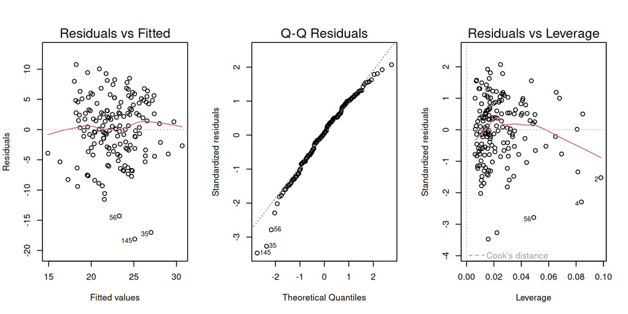

Figure 2.3: Diagnostic plots for linear model.

```r
par(mfrow=c(1, 3))
plot(fit_lin, which=c(1, 2, 5))
```

# 3 Logistic regression (week 3)

Logistic regression allows us to predict discrete outcomes based on explanatory variables, as opposed to linear regression where the output of the model is continuous (James et al. 2021). An example of this would be whether a student passes a class (true/false), while in linear regression we could predict the grade of the student. However, simple linear regression is not very suitable for classification tasks as it is not very reliable. Logistic regression instead models the conditional probability $p(X)$ of an outcome given the explanatory variables $X$ as $\exp\left(\frac{\hat p(X)}{1 - \hat p(X)}\right) = \hat f(X)$, which is then used to determine whether that outcome is likely to occur or not.

We are using student performance data[^3] from questionnaires and school reports to model student alcohol consumption based on data about the background and academic performance of the students. The data contains variables such as age, sex, academic performance (grades, attendance, failures), family background (job, education, support), personal data (health, alcohol consumption, how much going out with friends) among other variables. All of the variables in the data set are printed in the code snippet below. This data gives an overview on the life of each student, which can be used to predict habits such as alcohol consumption. The students will be classified into two groups: low alcohol use and high alcohol use. High alcohol use is defined as the mean of weekday and and weekend alcohol use exceeding some limit (2). To generate the data set, we use the R script [`data/create_alc.R`](https://github.com/Roninkoi/IODS-project/blob/master/data/create_alc.R). This script joins two data sets, collected from mathematics and Portuguese language students, to create a single data set consisting of students attending both classes. The data sets are joined by identifying each student using the background questions, and calculating the mean of the grades (and other class-specific variables) of the two classes for each student. The resulting data set better captures the academic performance of each student across subjects. The final data set consists of 35 variables and 370 students.

```r
# load data set
alc <- read_csv("./data/alc.csv", show_col_types = F)

# variables in the data set
print(colnames(alc))
```

```
##  [1] "school"     "sex"        "age"        "address"    "famsize"
##  [6] "Pstatus"    "Medu"       "Fedu"       "Mjob"       "Fjob"
## [11] "reason"     "guardian"   "traveltime" "studytime"  "schoolsup"
## [16] "famsup"     "activities" "nursery"    "higher"     "internet"
## [21] "romantic"   "famrel"     "freetime"   "goout"      "Dalc"
## [26] "Walc"       "health"     "failures"   "paid"       "absences"
## [31] "G1"         "G2"         "G3"         "alc_use"    "high_use"
```

```r
n_men <- nrow(filter(alc, sex == "M"))
n_women <- nrow(filter(alc, sex == "F"))
message("Number of students: ", n_men+n_women, " (", n_men, " men, ", n_women, " women)")
```

```
## Number of students: 370 (175 men, 195 women)
```

We will pick `sex` (M/F), `goout` (how much student goes out with friends), `absences` (number of school absences) and `G3` (final exam score) as the explanatory variables for our logistic regression model. We hypothesize that `G3` of each student is negatively correlated with alcohol consumption, and `goout` and `absences` are positively correlated. The students who drink a lot would be going out with their friends a lot, while attending school less than their peers who drink little. Social drinking when going out with friends would increase the alcohol consumption for these students. This would be associated with a lower final score, as the students are perhaps less interested in studying (and more interested in partying). We additionally hypothesize that there are more male heavy drinkers and fewer female heavy drinkers. This gives us 4 explanatory variables (`sex`, `goout`, `absences` and `G3`) to predict whether a student is a heavy drinker `high_use` (true/false).

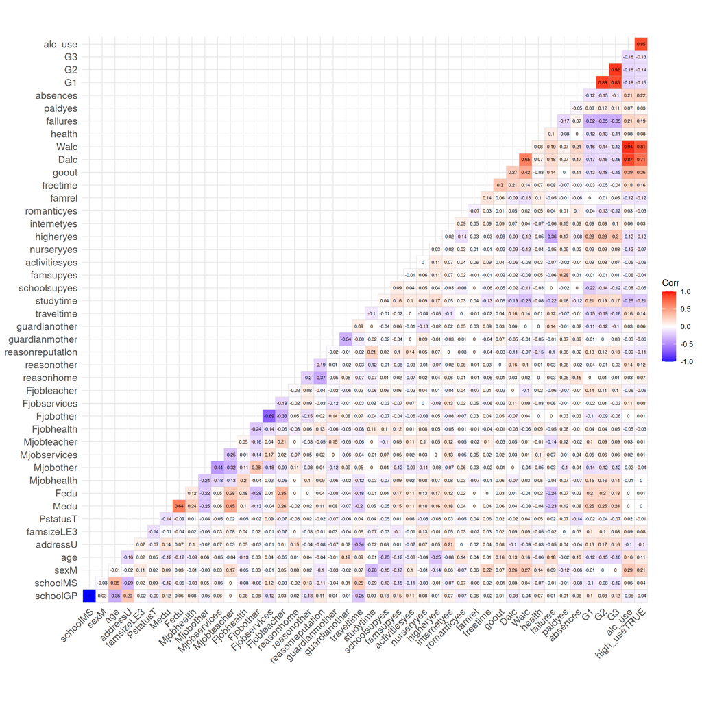

Figure 3.1: Correlation matrix for student alcohol consumption data set.

```r
model.matrix(~0+., data=alc) %>%
  cor(use="pairwise.complete.obs") %>%
  ggcorrplot(show.diag=FALSE, type="lower", lab=TRUE, lab_size=2)
```

We examine the relationships between variables in the data as well as our chosen model by plotting the correlation matrix (figure 3.1). In this matrix, the correlation coefficients between variables in the data set are visualized (red = positive, blue = negative). The correlation coefficients for the variables in our chosen model are:
$$\rho_{\text{high_use},\text{sex (M)}} = 0.21, \
\rho_{\text{high_use},\text{goout}} = 0.36, \\
\rho_{\text{high_use},\text{absences}} = 0.22, \
\rho_{\text{high_use},\text{G3}} = -0.13.$$
This suggests that the most significant variable in our model predicting high alcohol use is how often students go out with their friends, followed by the number of absences. This suggests that social drinking with friends contributes significantly to the alcohol intake of the students, possibly resulting in absences. In the group of heavy drinkers, a significant majority are men. These observations are in agreement with our previous hypothesis. The final exam score is negatively correlated with high alcohol use, but the correlation is perhaps less significant than initially thought. The number of failures, amount of study time and free time have higher correlation coefficients, so the final exam score may be a worse predictor of alcohol use. It should be noted that high alcohol use is most highly correlated with mean alcohol use and weekday/weekend alcohol use, as it is defined using those variables, so these variables will not be included in any model.

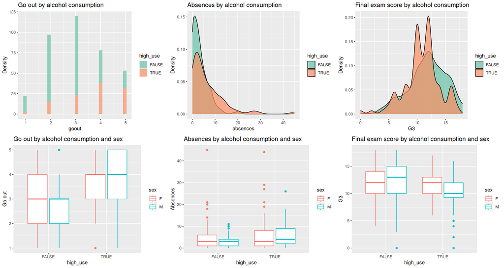

Figure 3.2: Distributions and box plots for different variables.

```r
h1 <- ggplot(alc, aes(x = goout, fill = high_use)) +
   geom_histogram(alpha = 0.7) + ylab("Density") +
  ggtitle("Go out by alcohol consumption") +
  scale_fill_brewer(palette="Set2")
h2 <- ggplot(alc, aes(x = absences, fill = high_use)) +
  geom_density(alpha = 0.7) + ylab("Density") +
  ggtitle("Absences by alcohol consumption") +
  scale_fill_brewer(palette="Set2")
h3 <- ggplot(alc, aes(x = G3, fill = high_use)) +
  geom_density(alpha = 0.7) + ylab("Density") +
  ggtitle("Final exam score by alcohol consumption") +
  scale_fill_brewer(palette="Set2")

b1 <- ggplot(alc, aes(x = high_use, y = goout, col = sex)) + geom_boxplot() +
  ylab("Go out") + ggtitle("Go out by alcohol consumption and sex")
b2 <- ggplot(alc, aes(x = high_use, y = absences, col = sex)) + geom_boxplot() +
  ylab("Absences") + ggtitle("Absences by alcohol consumption and sex")
b3 <- ggplot(alc, aes(x = high_use, y = G3, col = sex)) + geom_boxplot() +
  ylab("G3") + ggtitle("Final exam score by alcohol consumption and sex")

grid.arrange(h1, h2, h3, b1, b2, b3, ncol=3, nrow=2)
```

The distributions and box plots for our chosen variables are shown in figure 3.2. About 53% of students are female, so there are roughly equal numbers of male and female students. Looking at the distributions, we can see that the students who are heavy drinkers tend to go out more, tend to have more absences and tend to have lower exam scores. In the case of `goout` and `absences`, the variance of the distributions appears larger. The median final exam scores for light drinkers and heavy drinkers looks about the same, though the distributions look quite different. High-scoring students tend to be mostly light drinkers. The exam score distribution for heavy drinkers has many peaks, but this may be because there are fewer heavy drinkers. The box plots show these variables separated by sex. Overall, high alcohol consumption appears to affect men more than women, as there are greater differences between men that are light drinkers and men that are heavy drinkers. Notably, for women the median number of absences and test score appears to be the same, while for men alcohol consumption has a more negative impact. Additionally, alcohol use appears to change the variability of results for the different groups.

We fit a logistic regression model using our 4 chosen parameters using the function `glm()` with the parameter `family = "binomial"`. Since we have a factor variable `sex`, we subtract 1 from the formula to get separate coefficients for each sex. For the coefficients, we calculate the odds ratios (OR) and confidence intervals (CI) by exponentiating the output from the functions `coef()` and `confint()` respectively. The odds ratio tells us how much the outcome probability is affected by each coefficient. The full summary of the fitted model with coefficients, errors and $p$-values is shown in table 3.1. The $p$-values are calculated based on the Wald test.

Based on the odds ratios, the most significant variables contributing to high alcohol use are `goout` followed by `absences`. For men, the OR is larger than for women, so men are much more likely to be heavy drinkers. This agrees with our previous observations for these parameters, and agrees with our hypothesis. The exam score `G3` OR is less than 1, so a higher exam score decreases the probability of high alcohol use as per our previous observations. The $p$-values for the `sex`, `goout` and `absences` variables are all statistically significant ($< 0.05$), while the `G3` $p$-values are not. This disagrees with our hypothesis that the final exam score predicts alcohol use.

```r
# fit logistic regression
model <- glm(high_use ~ sex + goout + absences + G3 - 1, data = alc,
             family = "binomial")
model_summary <- summary(model)

# exponentiate coefficients to get odds ratio (and confidence interval)
odds_ratio <- coef(model) %>% exp
conf_int <- confint(model) %>% exp

fe <- data.frame("Variable"=c("Sex (F)", "Sex (M)",
                         "Go out", "Absences",
                         "G3"),
                 "Coefficient"=c(model_summary$coefficients[1,1],
                         model_summary$coefficients[2,1],
                         model_summary$coefficients[3,1],
                         model_summary$coefficients[4,1],
                         model_summary$coefficients[5,1]),
                 "Std.error"=c(model_summary$coefficients[1,2],
                         model_summary$coefficients[2,2],
                         model_summary$coefficients[3,2],
                         model_summary$coefficients[4,2],
                         model_summary$coefficients[5,2]),
                 "P-value"=c(model_summary$coefficients[1,4],
                         model_summary$coefficients[2,4],
                         model_summary$coefficients[3,4],
                         model_summary$coefficients[4,4],
                         model_summary$coefficients[5,4]),
                 "OR"=c(odds_ratio[1],
                         odds_ratio[2],
                         odds_ratio[3],
                         odds_ratio[4],
                         odds_ratio[5]),
                 "CI2.5"=c(conf_int[1,1],
                         conf_int[2,1],
                         conf_int[3,1],
                         conf_int[4,1],
                         conf_int[5,1]),
                 "CI97.5"=c(conf_int[1,2],
                         conf_int[2,2],
                         conf_int[3,2],
                         conf_int[4,2],
                         conf_int[5,2]))
fe <- format_engr(fe)
kable(fe, caption = "Fit summary for model with 4 parameters.")
```

Table 3.1: Fit summary for model with 4 parameters.

| Variable | Coefficient | Std.error | P.value | OR | CI2.5 | CI97.5 |
| --- | --- | --- | --- | --- | --- | --- |
| Sex (F) | $-3.580$ | ${703.6}\times 10^{-3}$ | ${360.2}\times 10^{-9}$ | ${27.87}\times 10^{-3}$ | ${6.655}\times 10^{-3}$ | ${105.7}\times 10^{-3}$ |
| Sex (M) | $-2.562$ | ${683.5}\times 10^{-3}$ | ${178.2}\times 10^{-6}$ | ${77.17}\times 10^{-3}$ | ${19.40}\times 10^{-3}$ | ${285.3}\times 10^{-3}$ |
| Go out | ${705.5}\times 10^{-3}$ | ${121.7}\times 10^{-3}$ | ${6.681}\times 10^{-9}$ | $2.025$ | $1.605$ | $2.588$ |
| Absences | ${82.63}\times 10^{-3}$ | ${22.67}\times 10^{-3}$ | ${267.9}\times 10^{-6}$ | $1.086$ | $1.040$ | $1.138$ |
| G3 | ${-45.08}\times 10^{-3}$ | ${39.85}\times 10^{-3}$ | ${258.0}\times 10^{-3}$ | ${955.9}\times 10^{-3}$ | ${883.8}\times 10^{-3}$ | $1.034$ |

We fit the model again, this time with only the variables `sex`, `goout` and `absences`. Now all of the variables in our model have a statistically significant relationship with alcohol use. Using this model, we predict the response for the training data and calculate the training loss as $L_\text{train} = \text{E}[|\text{high_use}-p_\text{high_use}| > 0.5]$, where $\text{high_use}$ is the training data and $p_\text{high_use}$ is the model prediction (probability). The training loss represents the fraction of students that were misclassified. For our model with 3 parameters, we get $L_\text{train} = 0.2108$, which means that the model classifies the alcohol use of students with 79% accuracy. According to the cross tabulation of predictions vs. actual values in table 3.2, we can see that the model is underestimating the number of heavy drinkers. It most commonly misclassifies students that are heavy drinkers as light drinkers. This is nonetheless significantly better than guessing (e.g. flipping a coin), which would give us a probability of $p(\text{TT} \cup \text{FF}) = 0.5 \times 0.7 + 0.5 \times 0.3 = 0.5$. We also calculate this random guess loss `random_err` in the code below, which gives a 50% error for random guessing.

The values for `high_use` and predictions from the model are plotted in figure 3.3. Predictions with probabilities $>0.5$ are classified as `high_use`, visualized using colors. We can see how the prediction errors for heavy drinkers are visible in this plot.

```r
# fit better logistic regression model
model <- glm(high_use ~ sex + goout + absences - 1, data = alc,
             family = "binomial")
model_summary <- summary(model)

# loss function
loss <- function(data, fit) mean(abs(data - fit) > 0.5)

# add predicted values for data set
alc_model <- data.frame(high_use=alc$high_use,
                        high_use_prob=predict(model, type = "response"))
alc_model <- mutate(alc_model, high_use_predict=high_use_prob>0.5)

# calculate prediction error for random guess
n_rand <- 100
random_err <- 0
for (i in 1:n_rand) {
  alc_random <- data.frame(high_use=alc$high_use,
                          high_use_prob=runif(nrow(alc), 0.0, 1.0))
  alc_random <- mutate(alc_random, high_use_predict=high_use_prob>0.5)

  random_err <- random_err +
    loss(alc_random$high_use, alc_random$high_use_prob) / n_rand
}

# cross tabulation
cross_tab <- table(high_use = alc_model$high_use,
      prediction = alc_model$high_use_predict) %>% prop.table %>% addmargins

# training error
train_err <- loss(alc_model$high_use, alc_model$high_use_prob)

message("Train err: ", train_err, ", random: ", random_err)

kable(data.frame(Prediction.FALSE=cross_tab[,1],
                 Prediction.TRUE=cross_tab[,2],
                 Sum=cross_tab[,3]), caption = "Cross tabulation.")
```

Table 3.2: Cross tabulation.

|  | Prediction.FALSE | Prediction.TRUE | Sum |
| --- | --- | --- | --- |
| FALSE | 0.6540541 | 0.0459459 | 0.7 |
| TRUE | 0.1648649 | 0.1351351 | 0.3 |
| Sum | 0.8189189 | 0.1810811 | 1.0 |

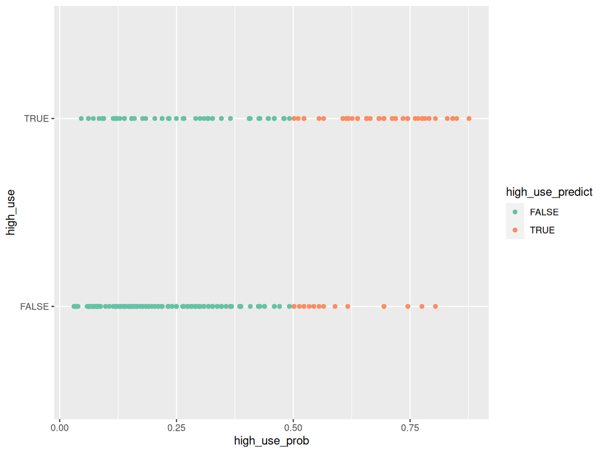

Figure 3.3: Actual values for alcohol use vs. predicted.

```r
ggplot(alc_model, aes(x = high_use_prob,
                     y = high_use, col = high_use_predict)) +
  geom_point() + scale_color_brewer(palette="Set2")
```

To get a better estimate for the error (using the training set) for our model, we use 10-fold cross-validation (CV). The function `cv.glm()` is used with the parameter `K = 10`. This divides the test set in 10 folds, and fits the model 10 times. Since CV doesn’t use the training set for testing, we can get a better estimate of the error by averaging.

```r
cv_err <- 0
n_cv <- 100
for (i in 1:n_cv) {
  alc_cv <- cv.glm(data = alc,
                   cost = loss,
                   glmfit = model, K = 10)
  cv_err <- cv_err + alc_cv$delta[1] / n_cv
}
message("CV: ", cv_err)
```

```
## CV: 0.214891891891892
```

Finally, we attempt to find a better model by running cross-validation for a large number of different variables. The R code below starts from a list of some of the most highly correlated variables, and starts fitting models in a loop. For each fit, we remove the variable with the largest $p$-value from the set of fitted variables. This removes the worst variable from the model, so the number of parameters in the model decreases, i.e. the model flexibility decreases. For each of these fits, we additionally record the training loss $L_\text{train}$ and cross-validation error $L_\text{CV}$. The refitting process is continued until we run out of variables.

The best found model has a training loss of $L_\text{train}=0.2162$ and CV error $L_\text{CV}=0.2094$. This model consists of the 5 variables `sex`, `goout`, `absences`, `famrel` and `studytime`. All of these variables are statistically significant.

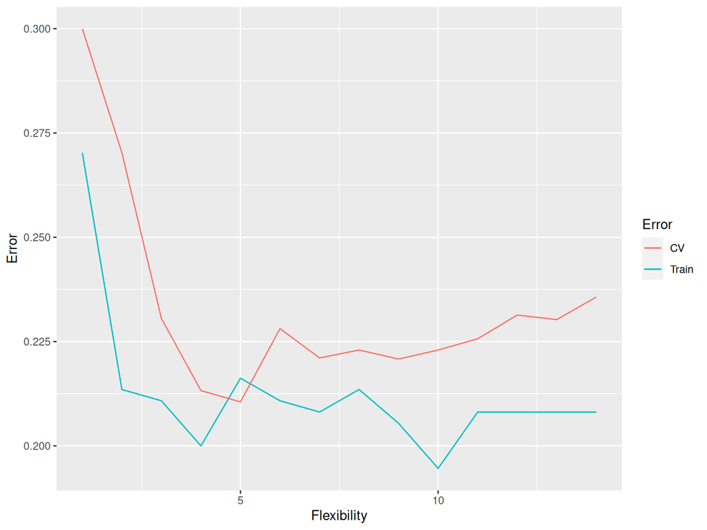

Figure 3.4: Training and CV error vs. model flexibilty.

```r
flex_err <- data.frame(matrix(nrow = 0, ncol = 3))

# intial model variables to fit
model_variables <- c("age", "sex", "goout", "failures", "absences",
                     "freetime", "famrel", "higher", "studytime",
                     "traveltime", "address", "G1", "G2", "G3")
alc_i <- select(alc, all_of(c("high_use", model_variables))) # initial data set
n_var <- length(model_variables)
for (i in 1:n_var) { # loop through models
  # fit model with all columns in alc_i
  model_i <- glm(high_use ~ ., data = alc_i,
             family = "binomial")
  model_i_summary <- summary(model_i)
  #print(model_i_summary)
  # model flexibility
  flex = length(model_variables)

  # get index of variable with greatest p-value (not intercept)
  max_p <- which.max(model_i_summary$coefficients[2:(length(model_variables)+1),4])
  if (max_p > 0) { # remove largest p-value variable from data set
    rm_col <- model_variables[max_p]
    model_variables <- model_variables[-max_p]
    alc_i <- select(alc_i, -one_of(rm_col))
  }

  # calculate training error
  prob_i <- predict(model_i, type = "response")
  train_err_i <- loss(alc_i$high_use, prob_i)
  #message("Train loss: ", train_err_i)

  # calculate CV error
  cv_err <- 0
  n_cv <- 10
  for (i in 1:n_cv) {
    alc_cv <- cv.glm(data = alc_i,
                     cost = loss,
                     glmfit = model_i, K = 10)
    cv_err <- cv_err + alc_cv$delta[1] / n_cv
  }
  #message("CV: ", cv_err)

  flex_err <- rbind(flex_err, data.frame(flex=flex,
                                         train_err=train_err_i, cv_err=cv_err))
}
ggplot() +
  geom_line(data = flex_err, aes(x = flex, y = train_err, col="Train")) +
  geom_line(data = flex_err, aes(x = flex, y = cv_err, col="CV")) +
  labs(x = "Flexibility", y="Error", color="Error")
```

Harrison, Ewen, and Riinu Pius. 2021. *R for Health Data Science*. https://argoshare.is.ed.ac.uk/healthyr_book/.

James, Gareth, Daniela Witten, Trevor Hastie, and Robert Tibshirani. 2021. *An Introduction to Statistical Learning: with Applications in R*. Springer.

Vehkalahti, Kimmo. 2020. “IODS-project: Template for the IODS course.” https://github.com/KimmoVehkalahti/IODS-project/.

Vehkalahti, Kimmo, and Brian Everitt. 2019. *Multivariate Analysis for the Behavioral Sciences*. CRC Press.

[^1]: http://www.helsinki.fi/~kvehkala/JYTmooc/JYTOPKYS3-data.txt
[^2]: http://www.helsinki.fi/~kvehkala/JYTmooc/JYTOPKYS2-meta.txt
[^3]: http://www.archive.ics.uci.edu/dataset/320/student+performance